# Reactivity

# Basic Reactivity

## Demo 1

Run demo 1 code

## Reactive elements

`demos/demo01.R`

```r
library(tidyverse)
library(shiny)
data = readr::read_csv(here::here("data/weather.csv"))

shinyApp(
  ui = fluidPage(
    titlePanel("Temperature Forecasts"),
    sidebarLayout(
      sidebarPanel(
        radioButtons(
          "city", "Select a city",
          choices = c("Chicago", "Durham", "Sedona", "New York", "Los Angeles")
        )
      ),
      mainPanel(
        plotOutput("plot")
      )
    )
  ),
  server = function(input, output, session) {
    output$plot = renderPlot({
      data  %>%
        filter(city %in% input$city) %>%
        ggplot(aes(x=time, y=temp, color=city)) +
        geom_line()
    })
  }
)
```

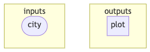

Our inputs and outputs are defined by the elements in our `ui`.

## Reactive expression

`demos/demo01.R`

```r
library(tidyverse)
library(shiny)
data = readr::read_csv(here::here("data/weather.csv"))

shinyApp(
  ui = fluidPage(
    titlePanel("Temperature Forecasts"),
    sidebarLayout(
      sidebarPanel(
        radioButtons(
          "city", "Select a city",
          choices = c("Chicago", "Durham", "Sedona", "New York", "Los Angeles")
        )
      ),
      mainPanel(
        plotOutput("plot")
      )
    )
  ),
  server = function(input, output, session) {
    output$plot = renderPlot({
      data  %>%
        filter(city %in% input$city) %>%
        ggplot(aes(x=time, y=temp, color=city)) +
        geom_line()
    })
  }
)
```

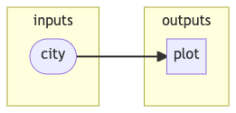

The “reactive” logic is defined in our `server` function - `shiny` takes care of figuring out what depends on what.

## Demo 02 - Adding an input

Run demo 2

## Demo 02 - Adding an input

`demos/demo02.R`

```r
library(tidyverse)
library(shiny)


shinyApp(
  ui = fluidPage(
    titlePanel("Temperature Forecasts"),
    sidebarLayout(
      sidebarPanel(
        radioButtons(
          "city", "Select a city",
          choices = c("Chicago", "Durham", "Sedona", "New York", "Los Angeles")
        ),
        checkboxInput("forecast", "Highlight forecasted data", value = FALSE)
      ),
      mainPanel( plotOutput("plot") )
    )
  ),
  server = function(input, output, session) {
    d = readr::read_csv(here::here("data/weather.csv"))

    output$plot = renderPlot({

      d_city = filter(d, city %in% input$city)

      if (input$forecast) {
        ggplot(d_city, aes(x=time, y=temp, color=source)) +
          geom_line() +
          scale_color_manual(values = c("red","black"))
      } else {
        ggplot(d_city, aes(x=time, y=temp), color=1) +
          geom_line()
      }
    })
  }
)
```

## Reactive graph

With these additions, what should our reactive graph look like now?

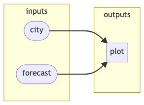

## Your turn - Exercise 03

Start with the code in `exercises/ex03.R` (based on `demo02.R`’s code)  
Add a `tableOutput()` to the app’s `mainPanel()`.

Once you have done that, add logic to the `server` function to render a table that shows the daily min and max temperature for each day of the week.

- You will need to use `renderTable()`
- `lubridate::wday()` will be useful along with `group_by()` & `summarize()`

`09:00`

## Reactive graph (again)

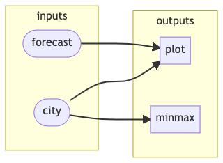

## reactlog

Another (more detailed) way of seeing the reactive graph (dynamically) for your app is using the `reactlog` package.

Run the following to log and show all of the reactive events occuring within `ex03_soln.R`,

```r
reactlog::reactlog_enable()

(source(here::here("exercises/solutions/ex03_soln.R")))

shiny::reactlogShow()
```

# User selected variables

## Demo 03 - Not just temperature

`demos/demo03.R`

```r
library(tidyverse)
library(shiny)
d = readr::read_csv(here::here("data/weather.csv"))

d_vars = d |>
  select(where(is.numeric)) |>
  names()

shinyApp(
  ui = fluidPage(
    titlePanel("Weather Forecasts"),
    sidebarLayout(
      sidebarPanel(
        radioButtons(
          "city", "Select a city",
          choices = c("Chicago", "Durham", "Sedona", "New York", "Los Angeles")
        ),
        selectInput(
          "var", "Select a variable",
          choices = d_vars, selected = "temp"
        )
      ),
      mainPanel(
        plotOutput("plot"),
        tableOutput("minmax")
      )
    )
  ),
  server = function(input, output, session) {
    output$plot = renderPlot({
      d |>
        filter(city %in% input$city) |>
        ggplot(aes(x=time, y=.data[[input$var]])) +
        ggtitle(input$var) +
        geom_line()
    })

    output$minmax = renderTable({
      d |>
        filter(city %in% input$city) |>
        mutate(
          day = lubridate::wday(time, label = TRUE, abbr = FALSE),
          date = as.character(lubridate::date(time))
        ) |>
        group_by(date, day) |>
        summarize(
          `min` = min(.data[[input$var]]),
          `max` = max(.data[[input$var]]),
          .groups = "drop"
        )
    })
  }
)
```

## `.data` & `.env`

These are an excellent option for avoiding some of the complexity around NSE with `rlang` (e.g. `{{`, `!!`, `enquo()`, etc.) when working with functions built with the tidy eval framework (e.g. `dplyr` and `ggplot2`).

> - `.data` retrieves data-variables from the data frame.
> - `.env` retrieves env-variables from the environment.

For more details see the rlang [.data and .env pronouns](https://rlang.r-lib.org/reference/dot-data.html) article.

# `reactive()` & `observe()`

## Don’t repeat yourself (DRY)

`demos/demo03.R`

```r
library(tidyverse)
library(shiny)
d = readr::read_csv(here::here("data/weather.csv"))

d_vars = d |>
  select(where(is.numeric)) |>
  names()

shinyApp(
  ui = fluidPage(
    titlePanel("Weather Forecasts"),
    sidebarLayout(
      sidebarPanel(
        radioButtons(
          "city", "Select a city",
          choices = c("Chicago", "Durham", "Sedona", "New York", "Los Angeles")
        ),
        selectInput(
          "var", "Select a variable",
          choices = d_vars, selected = "temp"
        )
      ),
      mainPanel(
        plotOutput("plot"),
        tableOutput("minmax")
      )
    )
  ),
  server = function(input, output, session) {
    output$plot = renderPlot({
      d |>
        filter(city %in% input$city) |>
        ggplot(aes(x=time, y=.data[[input$var]])) +
        ggtitle(input$var) +
        geom_line()
    })

    output$minmax = renderTable({
      d |>
        filter(city %in% input$city) |>
        mutate(
          day = lubridate::wday(time, label = TRUE, abbr = FALSE),
          date = as.character(lubridate::date(time))
        ) |>
        group_by(date, day) |>
        summarize(
          `min` = min(.data[[input$var]]),
          `max` = max(.data[[input$var]]),
          .groups = "drop"
        )
    })
  }
)
```

## Demo 04 - Using a reactive

`demos/demo04.R`

```r
library(tidyverse)
library(shiny)
d = readr::read_csv(here::here("data/weather.csv"))

d_vars = d |>
  select(where(is.numeric)) |>
  names()

shinyApp(
  ui = fluidPage(
    titlePanel("Weather Forecasts"),
    sidebarLayout(
      sidebarPanel(
        radioButtons(
          "city", "Select a city",
          choices = c("Chicago", "Durham", "Sedona", "New York", "Los Angeles")
        ),
        selectInput(
          "var", "Select a variable",
          choices = d_vars, selected = "temp"
        )
      ),
      mainPanel(
        plotOutput("plot"),
        tableOutput("minmax")
      )
    )
  ),
  server = function(input, output, session) {

    d_city = reactive({
      d |>
        filter(city %in% input$city)
    })

    output$plot = renderPlot({
      d_city() |>
        ggplot(aes(x=time, y=.data[[input$var]], color=city)) +
        ggtitle(input$var) +
        geom_line()
    })

    output$minmax = renderTable({
      d_city() |>
        mutate(
          day = lubridate::wday(time, label = TRUE, abbr = FALSE),
          date = as.character(lubridate::date(time))
        ) |>
        group_by(date, day) |>
        summarize(
          `min` = min(.data[[input$var]]),
          `max` = max(.data[[input$var]]),
          .groups = "drop"
        )
    })
  }
)
```

## Reactive expressions

These are an example of a “reactive conductor” as they exist in between sources (e.g. an input) and endpoints (e.g. an output).

As such a `reactive()` depends on various upstream inputs and can be used to generate output.

Their primary use is similar to a function in an R script, they help to

- avoid repeating yourself
- decompose complex computations into smaller / more modular steps
- can improve computational efficiency by breaking up / simplifying reactive dependencies

## `reactive()` tips

- Code written similarly to `render*()` functions
- If `react_obj = reactive({...})` then any consumer must access value using `react_obj()` and *not* `react_obj`
  - think of `react_obj` as a function that returns the current value
  - Common cause of everyone’s my favorite R error ,

    ```
    ## Error: object of type 'closure' is not subsettable`
    ```

- Like `input` reactive expressions may only be used within a reactive context (e.g. `render*()`, `reactive()`, `observer()`, etc.)

  ```
  ## Error: Operation not allowed without an active reactive context. (You tried to do something that can only be done from inside a reactive expression or observer.)
  ```

## Reactive graph

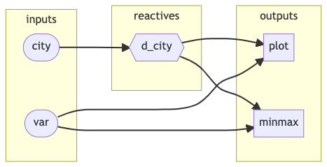

## `observer()`

These are constructed in the same way as a `reactive()` however an observer does not return a value, as such they are used for their side effects.

- The side effects in most cases involve sending data to the client broswer, e.g. updating a UI element
- While not obvious given their syntax - the results of the `render*()` functions are observers.

## Demo 05 - Cities AND regions

`demos/demo05.R`

```r
library(tidyverse)
library(shiny)
d = readr::read_csv(here::here("data/weather.csv"))

d_vars = d |>
  select(where(is.numeric)) |>
  names()

shinyApp(
  ui = fluidPage(
    titlePanel("Weather Forecasts"),
    sidebarLayout(
      sidebarPanel(
        selectInput(
          "region", "Select a region",
          choices = sort(unique(d$region))
        ),
        selectInput(
          "city", "Select a city",
          choices = c(),
          multiple = TRUE
        ),
        selectInput(
          "var", "Select a variable",
          choices = d_vars, selected = "temp"
        )
      ),
      mainPanel(
        plotOutput("plot")
      )
    )
  ),
  server = function(input, output, session) {

    d_city = reactive({
      req(input$city)
      d |>
        filter(city %in% input$city)
    })

    observe({
      cities = d |>
        filter(region == input$region) |>
        pull(city) |>
        unique() |>
        sort()

      updateSelectInput(
        inputId = "city",
        choices = cities
      )
    })

    output$plot = renderPlot({
      d_city() |>
        ggplot(aes(x=time, y=.data[[input$var]], color=city)) +
        ggtitle(input$var) +
        geom_line()
    })
  }
)
```

## Reactive graph

[figure not shown]

## Using `req()`

```r
Warning in min(.data[["temperature"]]) :
  no non-missing arguments to min; returning Inf
```

This can be a common occurrence, particularly at initialization (or if a user enters bad / unexpected input).

A good way to protect against this is to validate inputs - the simplest way is to use `req()` which checks if a value is [truthy](https://shiny.rstudio.com/reference/shiny/latest/isTruthy.html). Non-truthy values prevent further execution of the reactive code (and downstream consumer’s code).

More detailed validation and error reporting is possible with [`validate()`](https://shiny.rstudio.com/reference/shiny/1.7.0/validate.html) and [`need()`](https://shiny.rstudio.com/reference/shiny/1.7.0/validate.html).

## A cautionary example

```r
library(shiny)

shinyApp(
  ui = fluidPage(
    numericInput("n", "n", 0)
  ),
  server = function(input, output, session) {
    observeEvent(input$n, {
      updateNumericInput(inputId = "n", value = input$n + 1)
    })
  }
)
```

From [Mastering Shiny](https://mastering-shiny.org/action-dynamic.html#circular-references)

## Your turn - Exercise 04

Using the code provided in `exercise/ex04.R` as a starting point add another observer to the app that updates the `selectInput()` for `var` such that any variables that are constant (0 variance), for the currently selected cities, are removed.

For example, given this time of year most cities will have 0 risk of snow we would like to exclude the `snow` variable the `var` input.

*Hint* - think about what inputs / reactives would make the most sense to use for this.

`09:00`

[figure not shown]